# Projekt 2

## **Analiza skupień**

Yurii Petrenko, grupa 3

### Wstęp

Grupowanie (analiza skupień, klasteryzacja) (ang. data clustering) – pojęcie z zakresu eksploracji danych oraz uczenia maszynowego, wywodzące się z szerszego pojęcia, jakim jest klasyfikacja bezwzorcowa.

Analiza skupień jest metodą tzw. klasyfikacji bez nadzoru (ang. unsupervised learning). Jest to metoda dokonująca grupowania elementów we względnie jednorodne klasy. Podstawą grupowania w większości algorytmów jest podobieństwo pomiędzy elementami – wyrażone przy pomocy funkcji (metryki) podobieństwa.

Poprzez grupowanie można również rozwiązać problemy z gatunku odkrywania struktury w danych oraz dokonywanie uogólniania. Grupowanie polega na wyodrębnianiu grup (klas).

Wybrane cele dokonywania grupowania są następujące:

- uzyskanie jednorodnych przedmiotów badania, ułatwiających wyodrębnienie ich zasadniczych cech,
- zredukowanie dużej liczby danych pierwotnych do kilku podstawowych kategorii, które mogą być traktowane jako przedmioty dalszej analizy,
- zmniejszenie nakładu pracy i czasu analiz, których przedmiotem będzie uzyskanie klasyfikacji obiektów typowych,
- odkrycie nieznanej struktury analizowanych danych,
- porównywanie obiektów wielocechowych.

#### Etapy występujące w analizie skupień

1. Wybor obiektów i zmiennych
2. Wybór formuły normalizacji wartości zmiennych
3. Wybór miary odległości(etap ten nie występuje w analizie skupień bazującej bezpośrednio na macierzy danych)
4. Wybór metody klasyfikacji
5. Ustaleie liczby klas
6. Ocena wynników klasyfikacji
7. Opis(interpretacja) klass

#### Klastry

Pojedynczy klaster może być zdefiniowany jako:

- zbiór obiektów, które są „podobne”
- zbiór obiektów takich, że odległość pomiędzy dwoma dowolnymi obiektami należącymi do klastra jest mniejsza niż odległość po- między dowolnym obiektem należącym do klastra i dowolnym obiektem nie należącym do tego klastra
- spójny obszar przestrzeni wielowymiarowej, charakteryzujący się dużą gęstością występowania obiektów.

#### Hierarchiczne metody

Do podstawowych metod klasyfikacji zalicza się metody hierarchiczne(aglomeracyjne i deglomeracyjne) oraz metody optymalizujące wstępny podział zbioru obiektów w których znana jest liczba wyodrębnianych klas.

**Metody aglomeracyjne** (ang. agglomerative) – każda obserwacja tworzy na początku jednoelementowy klaster. Następnie pary klastrów są scalane, w każdej iteracji algorytmu łączone są ze sobą dwa najbardziej zbliżone klastry. Tworzone są tzw. „aglomeracje”. W tym typie podczas tworzenia klastrów, poruszamy się w górę hierarchii.

**Metody deglomeracyjne** (ang. divisive) – początkowo wszystkie obserwacje znajdują się w jednym klastrze. W następnych krokach klastry dzielone są na mniejsze i bardziej jednorodne. Podziały wykonywane są rekursywnie. W czasie tworzenia klastrów, poruszamy się w dół hierarchii.

#### Metody optymalizujące wstępny podział zbioru obiektów

Ze względu na to, że liczba możliwych podziałów jest ogromna, nie jest możliwe znależenie podziału optymalnego(optimum globalnego) z wykorzystaniem kryteriów, które bazują na macierzy odległości lub macierzy danych

Algorytmy optymalizacyjne, mające charakter iteracyjny, bazują więc na założeniu, że znany jest wstępny podział zbioru $n$ obiektów na $u$ klas. Zadaniem tych metod jest “poprawienie” dla zdefiniowanej funkcji-kryterium wstępnego poziału zbioru obiektów.

Do podstawowych metod optymalizacyjnych należą:

**k-średnich**(kmean) - algorytm ten polega na przenoszeniu obiektów ze skupienia do skupienia tak długo aż zostaną zoptymalizowane zmienności wewnątrz skupień oraz pomiędzy skupieniami. Oczywistym jest, iż podobieństwo w skupieniu powinno być jak największe, zaś osobne skupienia powinny się maksymalnie od siebie różnić. Zasada działania algorytmu jest następująca:

- Ustalamy liczbę skupień. Jedną z metod ustalenia ilości skupień jest umowny jej wybór i ewentualna późniejsza zmiana tej liczby w celu uzyskania lepszych wyników. Wybór liczby skupień może być oparty również na wynikach innych analiz.
- Ustalamy wstępne środki skupień. Środki skupień tak zwane centroidy możemy dobrać na kilka sposobów: losowy wybór k obserwacji, wybór k pierwszych obserwacji, dobór w taki sposób, aby zmaksymalizować odległości skupień. Jedną z najczęściej stosowanych metod jest kilkakrotne uruchomienie algorytmu i wybór najlepszego modelu, gdy wstępnie środki skupień były wybierane losowo.
- Obliczamy odległości obiektów od środków skupień. Wybór metryki jest bardzo istotnym etapem w algorytmie. Wpływa ona na to, które z obserwacji będą uważane za podobne, a które za zbyt różniące się od siebie. Najczęściej stosowaną odległością jest odległość euklidesowa.
- Przypisujemy obiekty do skupień Dla danej obserwacji porównujemy odległości od wszystkich skupień i przypisujemy ją do skupienia, do którego środka ma najbliżej.
- Ustalamy nowe środki skupień Najczęściej nowym środkiem skupienia jest punkt, którego współrzędne są średnią arytmetyczną współrzędnych punktów należących do danego skupienia.
- Wykonujemy kroki 3,4,5 do czasu, aż warunek zatrzymania zostanie spełniony. Najczęściej stosowanym warunkiem stopu jest ilość iteracji zadana na początku lub brak przesunięć obiektów pomiędzy skupieniami.

**k-medoid**(pam) - jest realizacją metody k-medoidowej, czyli takiej techniki grupowania, która dzieli zbiór danych zawierających $n$ obiektów na $k$ grup (skupień, ang. cluster) znanych a priori. Przydatnym narzędziem do oceny jakości grupowania jest sylwetka (ang. silhoutette). Oblicza się ją dla każdego obiektu podlegającego grupowaniu. Na jej podstawie można stwierdzić, czy obiekty zostały prawidłowo zgrupowane, czy też trafiły do złych klastrów.

Działanie tego algorytmu zbliżone jest do działania algorytmu centroidów, z tą różnicą, że centroidy zostają tu zastąpione przez medoidy, czyli najbardziej centralne obiekty ze zbioru danych reprezentujące daną grupę, dla których odległość od wszystkich pozostałych elementów wewnątrz danej grupy jest minimalna. Algorytm ten dąży do minimalizacji sumy odległości wszystkich elementów niebędących medoidami od najbliższych im medoidów.

Kolejną różnicą między algorytmem centroidów oraz metodą k-medoidową jest sposób definiowania dystansu między obserwacjami, bowiem algorytm PAM używa norm Manhattan zamiast odległości euklidesowej.

Zaletą tego algorytmu jest jego odporność na **obserwacje odstające** (ang. outliers) oraz szumy występujące w danych (ang. robustness). Główną wadą algorytmu PAM jest brak możliwości zastosowania tej metody dla dużych zbiorów danych (powyżej 65536 obserwacji).

**Celem projektu** jest podział danych z pliku piwo.csv na grupy względem różnych czynników(zaw.alkoholu,cena,dostępność,znajomość, preferencja) i podalsza interpretacja każdej z grup oraz porównania różnych metodyk grupowania(podziałowego,hirarhicznego)

### Przegląd wybranych narzędzi

Dla prowadzenia analizy wzykorzystane będzie środowisko $R-Studio$ i język programowania $R$

Zostały zainstalowanę pakiety:

$psych$ dla opisu statystyk opisowych

$clusterSim$ dla pracy z klasterami

$factoextra$ dla wizualizacji wyników

$gridExtra$ dla pracy z wykresami

```r
library(psych)
library(clusterSim)
library(factoextra)
library(gridExtra)
```

### Opis zbioru danych:

Zbiur danych składa się z 5 zmiennych i 20 obserwacji

1. **zawartosc.alk** -> procentowa zawartość alkoholu w piwie
2. **cena** -> cena piwa w zł
3. **dostepnosc** -> punktowy wskażnik dostępności piwa w sklepach
4. **znajomosc** -> punktowy wskażnik znajomości piwa
5. **preferencje** -> punktowy wskażnik preferencji piwa

Statystyki opisowe każdej zmiennej:

```
##               vars  n mean   sd median trimmed  mad  min  max range  skew
## zawartosc.alk    1 20 5.80 0.73   6.00    5.80 0.52 4.50 7.10  2.60  0.03
## cena             2 20 2.83 0.64   2.61    2.77 0.39 1.99 4.15  2.16  0.77
## dostepnosc       3 20 1.40 0.47   1.48    1.48 0.48 0.10 1.90  1.80 -1.18
## znajomosc        4 20 1.68 0.28   1.77    1.72 0.19 0.84 1.95  1.11 -1.39
## preferencje      5 20 1.02 0.59   0.94    0.93 0.28 0.34 2.65  2.31  1.20
##               kurtosis   se
## zawartosc.alk    -0.53 0.16
## cena             -0.55 0.14
## dostepnosc        0.92 0.11
## znajomosc         1.62 0.06
## preferencje       0.95 0.13
```

### Badanie empiryczne:

#### 1. Wybór obiektów i zmiennych

- W ramach procedury szukam zmiennych o odpowiedniej zmienności (>10%)

```
##        wsp_zm1   wsp_zm2   wsp_zm3   wsp_zm4   wsp_zm5
## [1,] 0.1252495 0.2267073 0.3387212 0.1649971 0.5841203
```

Po sprawdzaniu można zauważyć że wszystkie zmienne mają wsp. zmienności > 10%

- Sprawdzanie zmiennych niewspółliniowych (|r|<0.9)

```
##               zawartosc.alk  cena dostepnosc znajomosc preferencje
## zawartosc.alk          1.00 -0.39      -0.08     -0.19       -0.27
## cena                  -0.39  1.00       0.29      0.29        0.08
## dostepnosc            -0.08  0.29       1.00      0.82        0.61
## znajomosc             -0.19  0.29       0.82      1.00        0.62
## preferencje           -0.27  0.08       0.61      0.62        1.00
```

#### 2. Wybór formuły normalizacji zmiennych

- W ramach procedury zamieniam dane na porównywalne.

```
##              zawartosc.alk         cena   dostepnosc   znajomosc  preferencje
## Zywiec          -0,2686614  0,117105520  1,061553567  0,99293686  2,748925351
## Desperados       0,2824389  2,068864185  0,955926346  0,34183072 -0,213786601
## Kasztelan       -0,1308863 -0,554299461  0,850299125  0,59503867  1,940913000
## Wojak           -1,0953117 -1,132020026 -2,001635829 -0,96038156 -1,072299723
## Tyskie          -0,2686614 -0,460615045  1,061553567  0,92059174  0,779395246
## Heineken        -1,0953117  1,272546650  0,427790243  0,81207405  0,207053165
## Warka           -0,1308863 -0,366930629 -0,417227521  0,88441917  0,072384440
## Łomża            0,2824389 -0,351316560 -0,628481962 -0,05606747 -0,365288917
## Lech            -0,8197616 -0,007807035  0,850299125  0,81207405  0,038717258
## Perła            0,2824389 -0,413772837  0,322163023  0,41417585  1,065566287
## Specjal          0,2824389 -0,726054224 -2,741026373 -3,02221766 -0,988131770
## Żubr             0,2824389 -0,523071322  0,216535802  0,59503867 -0,314788145
## Redds           -1,7841870  1,631670244  0,005281361  0,05245022 -0,062284285
## Carlsberg        0,2824389  0,538685392  0,955926346  0,70355636 -0,331621736
## Somersby        -1,7841870  1,897109423 -0,205973080 -0,30927542 -0,028617104
## Tatra_Pils       0,2824389 -1,288160719  0,110908582 -1,35827975 -0,786128683
## Harnas           0,2824389 -1,303774788  0,533417464 -0,05606747  0,005050077
## Tatra_mocne      1,6601895 -0,320088421 -0,628481962 -0,85186387 -1,122800495
## Okocim_mocne     1,7979645 -0,179561797 -0,205973080  0,34183072 -0,432623279
## Debowe_mocne     1,6601895  0,101491451 -0,522854742 -0,85186387 -1,139634086
```

### Dane odstające:

Za pomocą statystyk opisowych po standaryzacji sprawdzam (min,max) czy występują obiekty na moduł więkrzych od 3

```
##  zawartosc.alk          cena           dostepnosc        znajomosc
##  Min.   :-1,7842   Min.   :-1,3038   Min.   :-2,7410   Min.   :-3,0222
##  1st Qu.:-0,4064   1st Qu.:-0,5309   1st Qu.:-0,4436   1st Qu.:-0,4449
##  Median : 0,2824   Median :-0,3357   Median : 0,1637   Median : 0,3418
##  Mean   : 0,0000   Mean   : 0,0000   Mean   : 0,0000   Mean   : 0,0000
##  3rd Qu.: 0,2824   3rd Qu.: 0,2225   3rd Qu.: 0,8503   3rd Qu.: 0,7307
##  Max.   : 1,7980   Max.   : 2,0689   Max.   : 1,0616   Max.   : 0,9929
##   preferencje
##  Min.   :-1,1396
##  1st Qu.:-0,5210
##  Median :-0,1380
##  Mean   : 0,0000
##  3rd Qu.: 0,1061
##  Max.   : 2,7489
```

Więc widać że w zmiennej znajomość występuje outlier, nie jest ta różnica bardzo znacząca więc podjęto decyzje zostawić tę dane

#### 3. Miara odległości

W ramach procedury buduję macierz odległości między obiektami.

W celach danego projektu będę korzystać z trzech metryk:

euklidesowa, Manhattan, Minkowski. Żeby potem poruwnać uzyskane wynniki

#### 4. Metoda klasyfikacji

W ramach procedury wybieram metodę klasyfikacji.

#### Metody hierarchiczne

**Metoda Warda** - opiera się na zasadzie analizy wariancji - wylicza różnicę między sumami kwadratów odchyleń odległości poszczególnych obiektów od środka ciężkości skupienia, do których te obiekty należą. Metoda ta wybierana jest najczęściej ze względu na jej dość uniwersalny charakter.

Sprawdzamy efekt grupowania dla różnych metod grupowania:

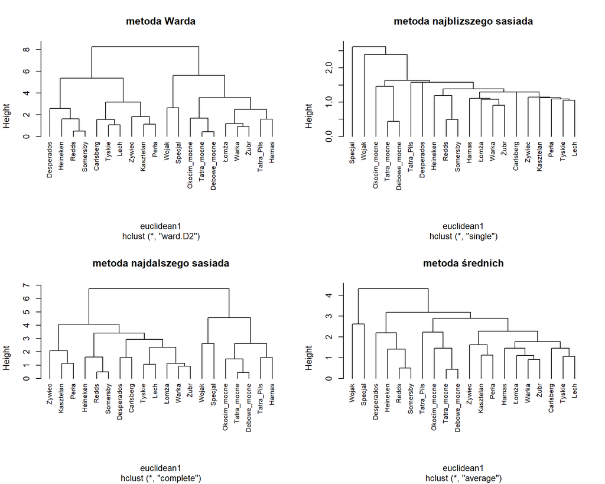

W każdym przypadku dendogram jest troche inny, czyli decydujemy że wybór metody grupowania ma wpływ na grupy. Ale również możemy zobaczyć że niektóre piwa zawsze są dobrane razem niezależnie od wybranej metody

Naprzykład piwa mocne (Okocim_mocne,Tatra_mocne,Debowe_mocne)

Łącząc do powyższych wykresów podział metodą warda jest stopniowo podobny do metody najdalszego sąsiada a dendogram metody najbliższego sąsiada jest podobny do dendogramu metody średnich

W dalszej analizie będziemy skupiać się bardziej na metodzie grupowania Warda

Należy jeszcze porównać wyniki dla różnych metryk

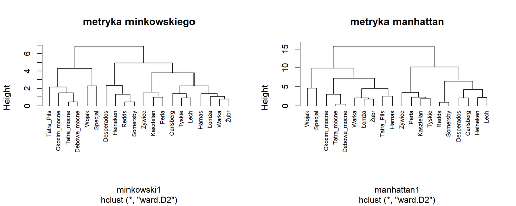

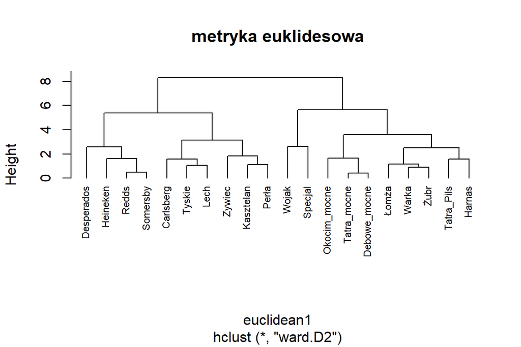

Jeżeli weźmiemy tylko metode Warda ale różne metryki to wynniki też będą się rożnić

Dla dalszej interpretacji należy ustalić liczbe klas.

#### 5. Ustalenie liczby klas

Przy grupowaniu hierarchicznym, określenie liczby skupień jest ważnym, choć nieprostym zadaniem. Oprócz metody „na oko” można wyznaczyć odpowiednie indeksy(np. index “silhouette”):

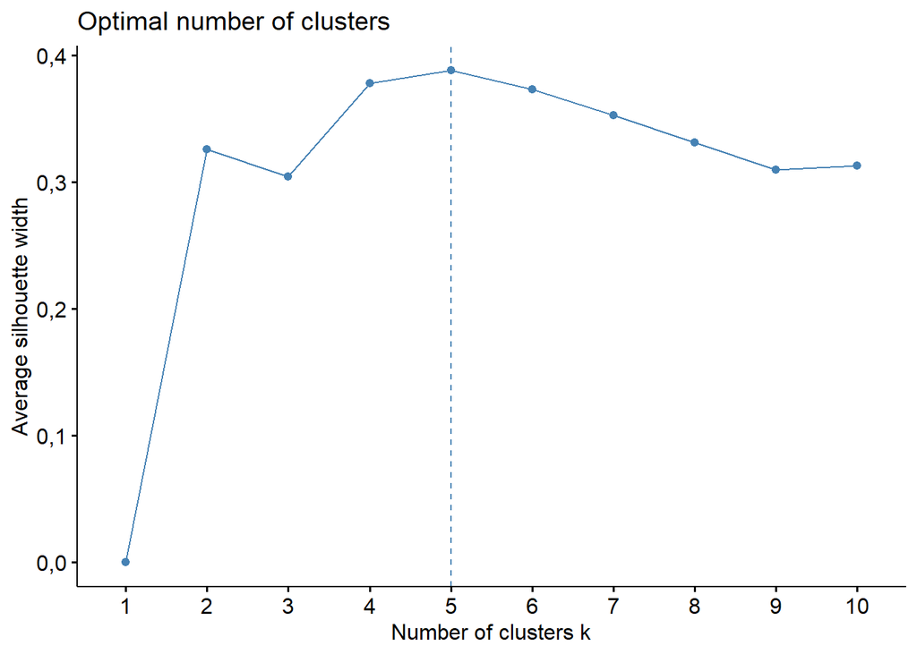

Indeksy wskazują że optymalna liczba klas jest równa 5

- Poruwnamy wynniki grupowania dla różnych metryk

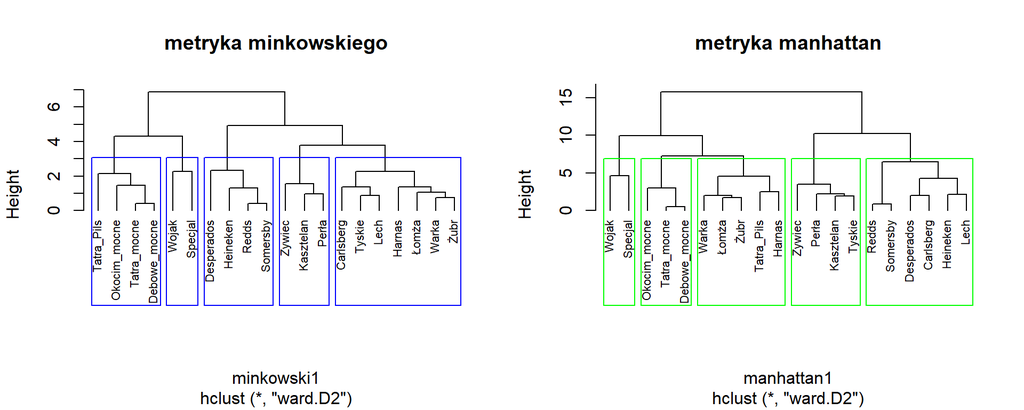

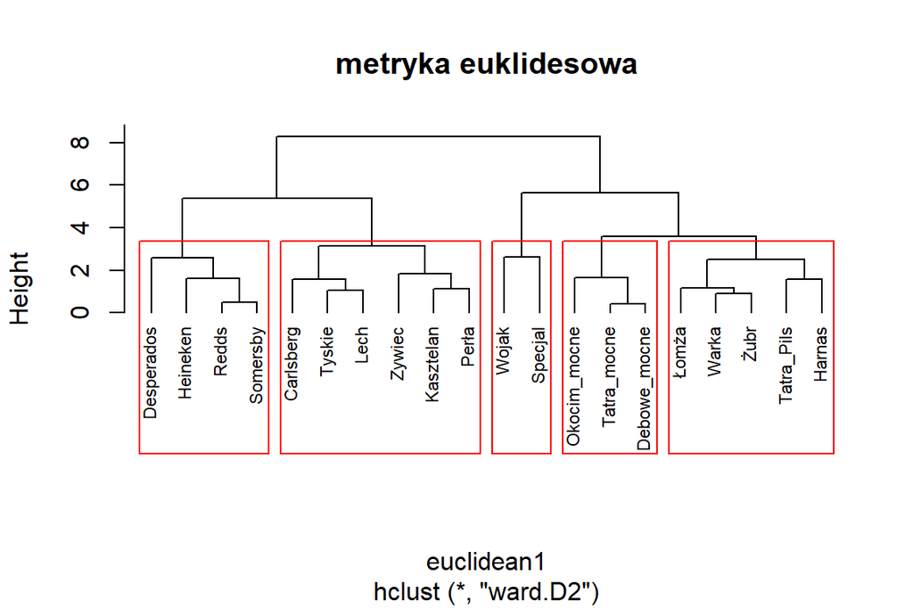

Widzimy że przyporządkowanie do grup jest dość podobne

Piwa(Wojak i Specjal) oraz (Okocim_mocne,Tatra_mocne,Debowe_mocne) są zawsze razem w osobnych grupie

Pozostałe piwa w różnych metrykach są rozrzucane między 3 grupami

Dla interpretacji najbardziej pasującym zbiorem jest **metryka Euclidesowa i metoda Warda**

- Wyznaczam średnią oraz odchylenie standardowe dla wszystkich zmiennych z każdej grupy (metryka Euclidesowa, metoda Warda)

```
##       Zywiec    Kasztelan       Tyskie         Lech        Perła    Carlsberg
##            1            1            1            1            1            1
##   Desperados     Heineken        Redds     Somersby        Wojak      Specjal
##            2            2            2            2            3            3
##        Warka        Łomża         Żubr   Tatra_Pils       Harnas  Tatra_mocne
##            4            4            4            4            4            5
## Okocim_mocne Debowe_mocne
##            5            5
```

```
##   Group.1 zawartosc.alk     cena dostepnosc znajomosc preferencje
## 1       1      5,683333 2,741667   1,800000    1,8800   1,6350000
## 2       2      5,000000 3,925000   1,537500    1,7375   1,0025000
## 3       3      5,500000 2,230000   0,275000    1,1250   0,4050000
## 4       4      5,940000 2,334000   1,380000    1,6760   0,8520000
## 5       5      7,033333 2,740000   1,183333    1,5500   0,4833333
```

```
##   Group.1 zawartosc.alk      cena dostepnosc  znajomosc preferencje
## 1       1    0,29944393 0,2706597  0,1303840 0,05932959  0,68686971
## 2       2    0,70710678 0,2221861  0,2428134 0,13098982  0,10340052
## 3       3    0,70710678 0,1838478  0,2474874 0,40305087  0,03535534
## 4       4    0,13416408 0,3124580  0,2252776 0,23891421  0,20364184
## 5       5    0,05773503 0,1374773  0,1040833 0,19052559  0,23965253
```

### Metody grupowania podziałowego

#### Metoda k-średnich

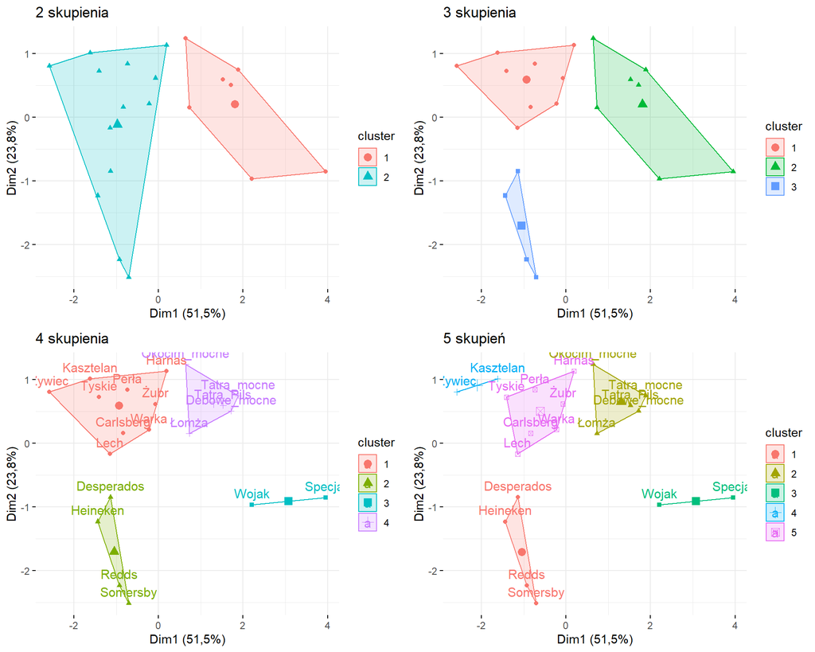

Na wykresie pokazano wynniki podziału metodą k-średnich dla różnej ilości klas

Wynniki są podobne do uzyskanych metodą hierarchiczną

Można zauważyć że dla 4 i 5 skupień znowu otrzymujemy osobną grupe dla piw(Specjal i Wojak) oraz dla piw smakowych(Desperados,Haineken, Redss, Somersby)

W danej metodzie do grupy piw mocnych(Okocim_mocne,Tatra_mocne,Debowe_mocne) zostało dopisane piwo Łomża które tam nie bardzo pasuje

Pozostałe piwa można zostawić w jednej grupie bo nie ma sensu odzielać Kasztelan i Żywiec

#### Metoda k-medoid

Wady algorytmu k-średnich są na tyle istotne, że często dąży się do zastosowania innych algorytmów w ramach grupy metod niehierarchicznych, ale takich, które wolne są od tychże wad. Jednym z takim algorymtów jest k-medoid, który to w odróżnieniu od algorytmu k-średnich w kolejnych etapach algorytmu nowe prototypy grup wyznaczane są spośród obiektów należących do rozpatrywanego zbioru.

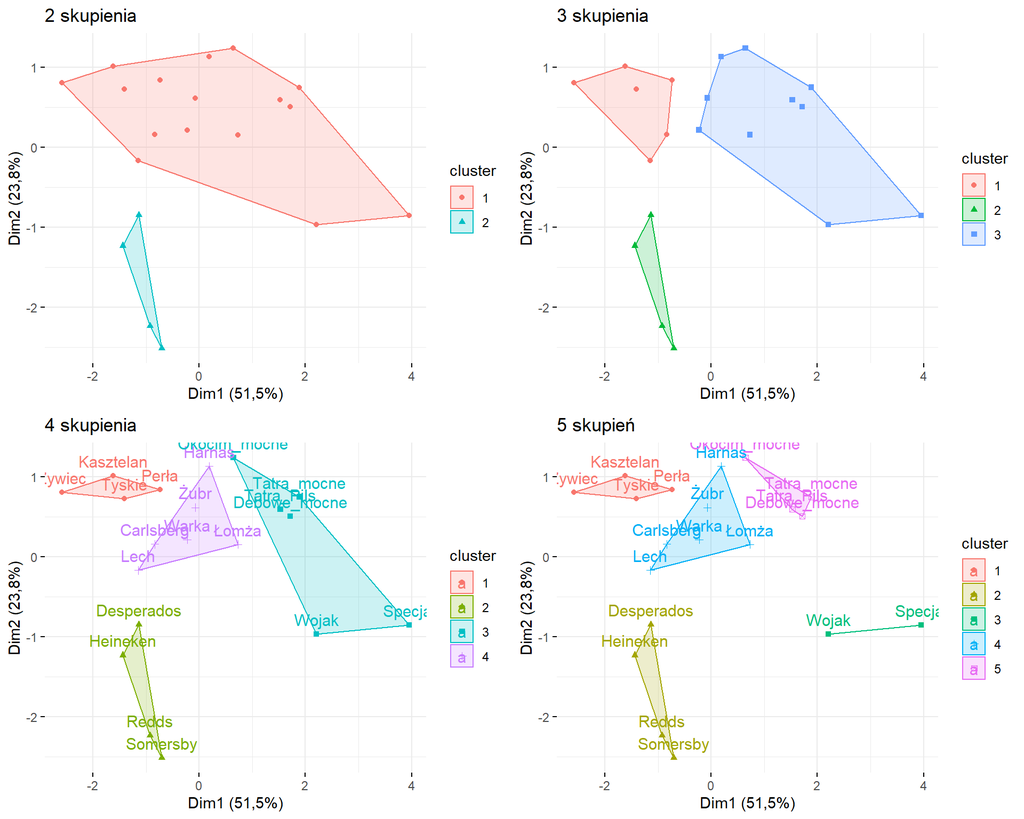

W metodzie pam wynniki praktycznie takie same jak wynniki uzyskane metodą hierarchiczną

```
##       Zywiec    Kasztelan       Tyskie        Perła   Desperados     Heineken
##            1            1            1            1            2            2
##        Redds     Somersby        Wojak      Specjal        Warka        Łomża
##            2            2            3            3            4            4
##         Lech         Żubr    Carlsberg       Harnas   Tatra_Pils  Tatra_mocne
##            4            4            4            4            5            5
## Okocim_mocne Debowe_mocne
##            5            5
```

```
##   Group.1 zawartosc.alk  cena dostepnosc znajomosc preferencje
## 1       1      5,725000 2,615   1,787500  1,877500   1,9875000
## 2       2      5,000000 3,925   1,537500  1,737500   1,0025000
## 3       3      5,500000 2,230   0,275000  1,125000   0,4050000
## 4       4      5,816667 2,610   1,516667  1,808333   0,9283333
## 5       5      6,775000 2,555   1,250000  1,487500   0,5000000
```

```
##   Group.1 zawartosc.alk      cena dostepnosc  znajomosc preferencje
## 1       1     0,1892969 0,1936492  0,1652019 0,07544314  0,53030652
## 2       2     0,7071068 0,2221861  0,2428134 0,13098982  0,10340052
## 3       3     0,7071068 0,1838478  0,2474874 0,40305087  0,03535534
## 4       4     0,3250641 0,3891015  0,3109126 0,11805366  0,12335585
## 5       5     0,5188127 0,3866523  0,1581139 0,19956202  0,19849433
```

#### 6. Interpretacja wynników:

Grupa 1 charakteryzuje się średnią zawartością alkoholu pomierną ceną oraz największą dostępnością znajomością i preferencją. Jest to piwo na codzień które można znależć praktycznie w każdym sklepie, wypić po ciężkej lub po zrobieniu projektu.

Grupa 2 charakteryzuje się najmniejszą zawartościu alkoholu ale największą ceną, jest to piwa raczej smakowe lub preferowane przez dam

Grupa 3 charakteryzuje się bardzo małą dostępnością oraz preferencją jest to piwo najtańsze i pije się raczej przez osób bardzo ekonomnych lub używane w wąskich kręgach

Gupa 4 charakteryzuje się średnią zawartością alkoholu, dostępnością, znajomością oraz preferencją Jest to piwo dla osób którzy szukają tej idealnej równowagi między ceną a jakością

Grupa 5 to są najbardziej alkoholowe piwo, dla osób którzy chcą się napić ale nie lubią mocnych alkoholi

Podsumowując, udało się podzielić piwa na grupy wykorzystując różne metodyki. Przeanalizowano i pokazano na wykresach i dendogranach jaki wpływ na grupowanie ma wybór metody klasyfikacji, metody grupowania oraz metryki. Zinterpretowano wynniki podziału i okazało się że są oni dość podobne(różnią się dokładnie kilka pozycji)

### Bibliografia:

- https://www.statsandr.com/blog/clustering-analysis-k-means-and-hierarchical-clustering-by-hand-and-in-r/#:~:text=The%20optimal%20number%20of%20clusters,a%20different%20number%20of%20clusters.
- https://www.researchgate.net/profile/Marek_Walesiak/publication/309399266_Wybrane_zagadnienia_klasyfikacji_obiektow_z_wykorzystaniem_programu_komputerowego_clusterSim_dla_srodowiska_R/links/580f325a08ae009606bb5f71/Wybrane-zagadnienia-klasyfikacji-obiektow-z-wykorzystaniem-programu-komputerowego-clusterSim-dla-srodowiska-R.pdf
- https://qastack.com.ua/programming/15376075/cluster-analysis-in-r-determine-the-optimal-number-of-clusters
- https://rpubs.com/katarzynawitan/664935
- http://keii.ue.wroc.pl/pracownicy/mw/2007_Walesiak_PN_AE_1169_Taksonomia_14.pdf
- https://uc-r.github.io/hc_clustering
- https://pbiecek.github.io/NaPrzelajDataMiningR/part-3.html
- Redakcja naukowa PWN, Marek Walesiak, Eugeniusz Gatnar,“Statystyczna analiza danych z wykorzystaniem programu R”,Warszawa,2009